[figure not shown]

# 1.1 TARNet (Treatment-Agnostic Representation Network)

This notebook demonstrates how to fit a **TARNet** (Treatment-Agnostic Representation Network) using **PyDeepCausalML**.

> **Note:** TARNet requires **PyTorch**. The `TARNet` estimator in `pydeepcausalml.effect` trains a deep shared-representation architecture with two treatment-specific outcome heads.

## Overview

TARNet is a neural network architecture for **causal inference**, specifically designed to estimate **individualized treatment effects (ITE)** from observational data. It was introduced by Shalit, Johansson, and Sontag (2017) in *"Estimating individual treatment effects: generalization bounds and algorithms."*

## Architecture

Two core challenges motivate TARNet's design:

- **The fundamental problem of causal inference:** For any individual, only one potential outcome is ever observed.
- **Selection bias:** In observational data, treatment assignment is rarely random — sicker patients may be more likely to receive treatment, confounding naive effect estimates.

[figure not shown]

TARNet addresses both through a three-part architecture:

### 1. Shared Representation Network (Φ)

Input covariates **X** pass through a deep network that produces a learned representation Φ(x).

### 2. Treatment-Specific Heads ($h_0$ and $h_1$)

- $h_0(\Phi(x))$ — predicts the potential outcome under *control*
- $h_1(\Phi(x))$ — predicts the potential outcome under *treatment*

### 3. ITE Estimation

$$\text{ITE}(x) = \hat{y}_1 - \hat{y}_0 = h_1(\Phi(x)) - h_0(\Phi(x))$$

## Why "Treatment-Agnostic"?

The shared encoder Φ is trained to be **agnostic to treatment assignment** — encoding a patient's underlying features, not which group they belonged to.

The related **CFRNet** variant extends TARNet by adding an **IPM regularizer** that explicitly penalizes distributional divergence between treated and control representations.

## TARNet vs. Other Approaches

| Approach | Key idea | Limitation |
| --- | --- | --- |
| **S-Learner** | Single model; treatment as a feature | Treatment effect can be smoothed away |
| **T-Learner** | Separate models per treatment arm | No shared learning; high variance |
| **TARNet** | Shared representation + separate heads | Balances shared features with arm-specific prediction |
| **CFRNet** | TARNet + IPM regularizer | More aggressive covariate shift correction |

## Implementation in Python

`TARNet` is implemented in **PyDeepCausalML** as `pydeepcausalml.effect.TARNet`. It trains a PyTorch neural network with a shared encoder and two outcome heads.

### Check and Install Required Python Packages

The following packages are used in this notebook. Install any missing packages with the cell below:

`numpy`, `pandas`, `scipy`, `torch`, `scikit-learn`, `matplotlib`, `seaborn`, `causaldata`, `pydeepcausalml`

```python
import importlib
import subprocess
import sys
from pathlib import Path

PACKAGES = [
    "numpy", "pandas", "scipy", "torch", "scikit-learn",
    "matplotlib", "seaborn", "causaldata",
]

for pkg in PACKAGES:
    mod = "sklearn" if pkg == "scikit-learn" else pkg
    try:
        importlib.import_module(mod)
    except ImportError:
        subprocess.check_call([sys.executable, "-m", "pip", "install", "-q", pkg])

try:
    import pydeepcausalml  # noqa: F401
except ImportError:
    repo_root = Path("..").resolve()
    subprocess.check_call([sys.executable, "-m", "pip", "install", "-q", "-e", str(repo_root)])

print("Packages ready.")
```

```
Packages ready.
```

### Verify imports

```python
import numpy as np
import pandas as pd
import torch
import matplotlib.pyplot as plt
import seaborn as sns
from pydeepcausalml import set_seed

print("torch:", torch.__version__)
print("cuda:", torch.cuda.is_available())
```

```
torch: 2.10.0+cu128
cuda: False
```

## Load data and prepare (X, t, y)

We use **NSW (`nsw_mixtape`)** from **causaldata**: treatment `treat`, outcome `re78`, covariates `age`, `educ`, `black`, `hisp`, `marr`, `nodegree`, `re74`, `re75`. After dropping incomplete rows, we split into **training** and **test** sets (80/20); covariates are standardized using the **training** mean and SD only.

```python
from pathlib import Path
import os
import numpy as np
import pandas as pd
from sklearn.ensemble import RandomForestRegressor
from sklearn.linear_model import ElasticNet, LogisticRegression, LinearRegression
from sklearn.model_selection import KFold


def load_nsw_mixtape() -> pd.DataFrame:
    """Load NSW (Lalonde) mixtape data (same variables as causaldata::nsw_mixtape)."""
    try:
        import causaldata.nsw_mixtape.data as nsw_data
        dta = Path(nsw_data.__file__).parent / "nsw_mixtape.dta"
        return pd.read_stata(dta)
    except Exception:
        pass
    url = (
        "https://raw.githubusercontent.com/NickCH-K/causaldata/master/"
        "data-raw/nsw_mixtape.dta"
    )
    return pd.read_stata(url)


def propensity_elastic_net(X: np.ndarray, treatment: np.ndarray) -> np.ndarray:
    model = LogisticRegression(
        penalty="elasticnet", solver="saga", l1_ratio=0.5, max_iter=2000
    )
    model.fit(X, treatment)
    return model.predict_proba(X)[:, 1]


class SLearner:
    def __init__(self, learner: str = "ranger"):
        self.learner = learner

    def fit(self, X, t, y):
        Xt = np.column_stack([X, t])
        if self.learner == "lm":
            self.model_ = LinearRegression().fit(Xt, y)
        else:
            self.model_ = RandomForestRegressor(
                n_estimators=100, random_state=42, n_jobs=-1
            ).fit(Xt, y)
        return self

    def predict(self, X):
        y0 = self.model_.predict(np.column_stack([X, np.zeros(len(X))]))
        y1 = self.model_.predict(np.column_stack([X, np.ones(len(X))]))
        return y1 - y0


class TLearner:
    def __init__(self, learner: str = "ranger"):
        self.learner = learner

    def fit(self, X, t, y):
        t = t.astype(int)
        if self.learner == "lm":
            self.m0_ = LinearRegression().fit(X[t == 0], y[t == 0])
            self.m1_ = LinearRegression().fit(X[t == 1], y[t == 1])
        else:
            self.m0_ = RandomForestRegressor(
                n_estimators=100, random_state=42, n_jobs=-1
            ).fit(X[t == 0], y[t == 0])
            self.m1_ = RandomForestRegressor(
                n_estimators=100, random_state=42, n_jobs=-1
            ).fit(X[t == 1], y[t == 1])
        return self

    def predict(self, X):
        return self.m1_.predict(X) - self.m0_.predict(X)


class XLearner:
    def __init__(self, learner: str = "ranger"):
        self.learner = learner

    def _reg(self):
        if self.learner == "lm":
            return LinearRegression()
        return RandomForestRegressor(n_estimators=100, random_state=42, n_jobs=-1)

    def fit(self, X, t, y, p=None):
        t = t.astype(int)
        p = propensity_elastic_net(X, t) if p is None else p
        m0, m1 = self._reg(), self._reg()
        m0.fit(X[t == 0], y[t == 0])
        m1.fit(X[t == 1], y[t == 1])
        d1 = y[t == 1] - m0.predict(X[t == 1])
        d0 = m1.predict(X[t == 0]) - y[t == 0]
        tau1 = self._reg().fit(X[t == 1], d1)
        tau0 = self._reg().fit(X[t == 0], d0)
        self.p_, self.tau0_, self.tau1_ = p, tau0, tau1
        return self

    def predict(self, X):
        return self.p_ * self.tau0_.predict(X) + (1 - self.p_) * self.tau1_.predict(X)


class RLearner:
    def __init__(self, learner: str = "ranger", n_fold: int = 3):
        self.learner = learner
        self.n_fold = n_fold

    def _reg(self):
        if self.learner == "lm":
            return LinearRegression()
        return RandomForestRegressor(n_estimators=100, random_state=42, n_jobs=-1)

    def fit(self, X, t, y, p=None):
        t = t.astype(int).astype(float)
        p = propensity_elastic_net(X, t) if p is None else p
        e = t - p
        m = self._reg()
        kf = KFold(n_splits=self.n_fold, shuffle=True, random_state=42)
        y_hat = np.zeros_like(y, dtype=float)
        for tr, va in kf.split(X):
            m.fit(X[tr], y[tr])
            y_hat[va] = m.predict(X[va])
        resid = y - y_hat
        tau = self._reg()
        tau.fit(X, resid / (e + 1e-6), sample_weight=e**2)
        self.tau_ = tau
        return self

    def predict(self, X):
        return self.tau_.predict(X)


def get_cumgain(df_preds, outcome_col="y", treatment_col="w", treatment_effect_col="tau", normalize=True):
    """Cumulative gain curve (CausalML-style AUUC helper)."""
    y = df_preds[outcome_col].to_numpy()
    w = df_preds[treatment_col].to_numpy()
    tau = df_preds[treatment_effect_col].to_numpy()
    model_cols = [c for c in df_preds.columns if c not in {outcome_col, treatment_col, treatment_effect_col}]
    n = len(df_preds)
    out = {}
    for col in model_cols:
        scores = df_preds[col].to_numpy()
        order = np.argsort(-scores)
        cum = []
        treated_so_far = control_so_far = 0.0
        for i, idx in enumerate(order, start=1):
            if w[idx] == 1:
                treated_so_far += y[idx]
            else:
                control_so_far += y[idx]
            lift = treated_so_far / max((w[order[:i]] == 1).sum(), 1) - control_so_far / max(
                (w[order[:i]] == 0).sum(), 1
            )
            cum.append(lift)
        curve = np.array(cum)
        if normalize and curve[-1] != 0:
            curve = curve / np.abs(curve[-1])
        out[col] = curve
    out[treatment_effect_col] = out.get(treatment_effect_col, out[model_cols[0]])
    return pd.DataFrame(out)


def plot_gain(df_preds, outcome_col="y", treatment_col="w", treatment_effect_col="tau", model_cols=None, main="", normalize=True):
    import matplotlib.pyplot as plt

    gain = get_cumgain(df_preds, outcome_col, treatment_col, treatment_effect_col, normalize)
    model_cols = model_cols or [c for c in gain.columns]
    plt.figure(figsize=(8, 5))
    for col in model_cols:
        if col in gain.columns:
            plt.plot(gain[col].values, label=col)
    plt.xlabel("Population fraction targeted")
    plt.ylabel("Cumulative gain" + (" (normalized)" if normalize else ""))
    plt.title(main)
    plt.legend()
    plt.tight_layout()
    plt.show()


def load_ihdp(replications: int = 2, random_state: int = 1):
    base_url = "https://raw.githubusercontent.com/uber/causalml/master/docs/examples/data"
    cols = ["treatment", "y_factual", "y_cfactual", "mu0", "mu1"] + [f"X{i}" for i in range(25)]
    parts = []
    for i in range(1, 10):
        url = f"{base_url}/ihdp_npci_{i}.csv"
        tmp = pd.read_csv(url, header=None)
        tmp.columns = cols[: tmp.shape[1]]
        parts.append(tmp)
    df = pd.concat(parts, ignore_index=True)
    if replications > 1:
        df = pd.concat([df] * replications, ignore_index=True)
    binfeats = [f"X{i}" for i in range(6, 25)]
    contfeats = [f"X{i}" for i in range(6)]
    xcols = binfeats + contfeats
    X = df[xcols].to_numpy(dtype=float)
    treatment = df["treatment"].to_numpy(dtype=int)
    y = df["y_factual"].to_numpy(dtype=float)
    tau = np.where(
        treatment == 1,
        df["y_factual"] - df["y_cfactual"],
        df["y_cfactual"] - df["y_factual"],
    )
    n = len(X)
    rng = np.random.default_rng(random_state)
    val_idx = rng.choice(n, size=int(0.2 * n), replace=False)
    train_idx = np.setdiff1d(np.arange(n), val_idx)
    return df, X, treatment, y, tau, train_idx, val_idx


def simulate_hidden_confounder(n=2000, p=5, sigma=1.0, adj=0, random_state=42):
    """Synthetic DGP with latent confounder (CausalML-style benchmark)."""
    rng = np.random.default_rng(random_state)
    z = rng.normal(size=n)
    X = np.column_stack([z + rng.normal(scale=sigma, size=n) for _ in range(p)])
    e = 1 / (1 + np.exp(-(adj + 0.5 * z)))
    w = rng.binomial(1, e)
    b = 2 * z + rng.normal(scale=sigma, size=n)
    tau = 0.5 + 0.3 * z
    y = b + w * tau + rng.normal(scale=sigma, size=n)
    return {"X": X, "y": y, "w": w, "tau": tau, "b": b, "e": e}


def result_table(df_preds, tau_true):
    model_cols = [c for c in ["S", "T", "X", "R", "GANITE", "CEVAE"] if c in df_preds.columns]
    methods = model_cols + ["actual"]
    ate = [df_preds[m].mean() for m in model_cols] + [float(tau_true.mean())]
    mae = [float(np.mean(np.abs(df_preds[m] - tau_true))) for m in model_cols] + [np.nan]
    gain = get_cumgain(df_preds)
    auuc = [float(gain[m].mean()) if m in gain.columns else np.nan for m in model_cols]
    auuc.append(float(gain["tau"].mean()) if "tau" in gain.columns else np.nan)
    return pd.DataFrame({"Method": methods, "ATE": ate, "MAE": mae, "AUUC": auuc})


def synthetic_summary(preds, tau_ref, actual_ate):
    rows = []
    for name, p in preds.items():
        rows.append({
            "Method": name,
            "ATE": p.mean(),
            "MSE": np.mean((p - tau_ref) ** 2),
            "AbsPctErrorATE": abs(p.mean() / actual_ate - 1) if actual_ate != 0 else np.nan,
        })
    rows.append({"Method": "Actuals", "ATE": actual_ate, "MSE": np.nan, "AbsPctErrorATE": np.nan})
    return pd.DataFrame(rows)

import os
from pathlib import Path
from pydeepcausalml.effect import TARNet

FAST_RUN = os.getenv("PYDEEPCAUSALML_FAST_RENDER", "true").lower() == "true"
EPOCHS = 30 if FAST_RUN else 100
NUM_TREES = 100 if FAST_RUN else 500

set_seed(42)
df = load_nsw_mixtape()
y_col, t_col = "re78", "treat"
x_cols = ["age", "educ", "black", "hisp", "marr", "nodegree", "re74", "re75"]
df = df.dropna(subset=[y_col, t_col] + x_cols).copy()
df[t_col] = df[t_col].astype(int)

rng = np.random.default_rng(42)
idx = rng.choice(len(df), size=int(0.8 * len(df)), replace=False)
mask = np.zeros(len(df), dtype=bool)
mask[idx] = True
df_train, df_test = df[mask], df[~mask]

X_train_raw = df_train[x_cols].to_numpy(dtype=float)
X_test_raw = df_test[x_cols].to_numpy(dtype=float)
cm = X_train_raw.mean(axis=0)
cs = X_train_raw.std(axis=0)
cs[cs == 0] = 1.0
X_train = (X_train_raw - cm) / cs
X_test = (X_test_raw - cm) / cs
t_train = df_train[t_col].to_numpy(dtype=int)
y_train = df_train[y_col].to_numpy(dtype=float)
t_test = df_test[t_col].to_numpy(dtype=int)
y_test = df_test[y_col].to_numpy(dtype=float)

print(f"Train n = {len(X_train)} | Test n = {len(X_test)} | p = {X_train.shape[1]}")
```

```
Train n = 356 | Test n = 89 | p = 8
```

## Fit TARNet, S-Learner, and T-Learner

**TARNet** trains with mini-batches on the training fold. **S-Learner** and **T-Learner** use random forests on the same scaled covariates — a standard tree-based baseline.

```python
fit_tarnet = TARNet(
    repr_dim=100,
    head_dim=64,
    epochs=EPOCHS,
    batch_size=64,
    lr=1e-3,
    standardize=False,
    standardize_outcome=True,
    random_state=42,
    verbose=FAST_RUN,
    log_every=10,
).fit(X_train, t_train, y_train)

fit_sl = SLearner(learner="ranger").fit(X_train, t_train, y_train)
fit_tl = TLearner(learner="ranger").fit(X_train, t_train, y_train)
print("Fitted TARNet, S-Learner, and T-Learner")
```

```
Fitted TARNet, S-Learner, and T-Learner
```

## Predict and validate on the test set

For each unit, $\hat{\tau}(x) = \hat{Y}(1 \mid x) - \hat{Y}(0 \mid x)$. Because NSW has no counterfactual labels, we also report **factual outcome MSE** on the test set.

```python
def factual_mse_tarnet(est, X, t, y):
    y0, y1 = est.predict_potential_outcomes(X)
    y_hat = np.where(t.astype(bool), y1, y0)
    return float(np.mean((y - y_hat) ** 2))


def factual_mse_sl(est, X, t, y):
    y0 = est.model_.predict(np.column_stack([X, np.zeros(len(X))]))
    y1 = est.model_.predict(np.column_stack([X, np.ones(len(X))]))
    y_hat = np.where(t.astype(bool), y1, y0)
    return float(np.mean((y - y_hat) ** 2))


def factual_mse_tl(est, X, t, y):
    y_hat = np.where(t.astype(bool), est.m1_.predict(X), est.m0_.predict(X))
    return float(np.mean((y - y_hat) ** 2))


ite_tarnet = fit_tarnet.predict_cate(X_test)
ite_sl = fit_sl.predict(X_test)
ite_tl = fit_tl.predict(X_test)

compare_tbl = pd.DataFrame({
    "Learner": ["TARNet", "S-Learner (ranger)", "T-Learner (ranger)", "Naive diff-in-means"],
    "ATE_test": [ite_tarnet.mean(), ite_sl.mean(), ite_tl.mean(),
                 y_test[t_test == 1].mean() - y_test[t_test == 0].mean()],
    "Factual_MSE_test": [
        factual_mse_tarnet(fit_tarnet, X_test, t_test, y_test),
        factual_mse_sl(fit_sl, X_test, t_test, y_test),
        factual_mse_tl(fit_tl, X_test, t_test, y_test),
        np.nan,
    ],
})
display(compare_tbl.round(2))
```

|  | Learner | ATE_test | Factual_MSE_test |
| --- | --- | --- | --- |
| 0 | TARNet | 1783.31 | 54206052.77 |
| 1 | S-Learner (ranger) | 2008.26 | 57981011.75 |
| 2 | T-Learner (ranger) | 2687.54 | 63586336.35 |
| 3 | Naive diff-in-means | 2517.88 | NaN |

### CATE distributions on the test set

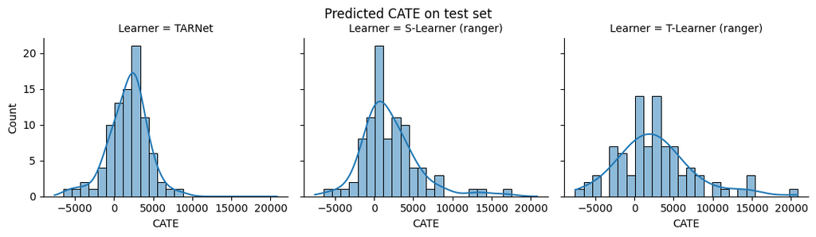

```python
cate_df = pd.DataFrame({
    "CATE": np.concatenate([ite_tarnet, ite_sl, ite_tl]),
    "Learner": ["TARNet"] * len(ite_tarnet)
    + ["S-Learner (ranger)"] * len(ite_sl)
    + ["T-Learner (ranger)"] * len(ite_tl),
})
g = sns.displot(cate_df, x="CATE", col="Learner", col_wrap=3, kde=True, height=3, aspect=1.2)
g.fig.suptitle("Predicted CATE on test set", y=1.02)
plt.show()
```

## Permutation-based feature importance (TARNet)

We measure how much **predicted CATE** depends on each covariate using permutation importance on the test fold.

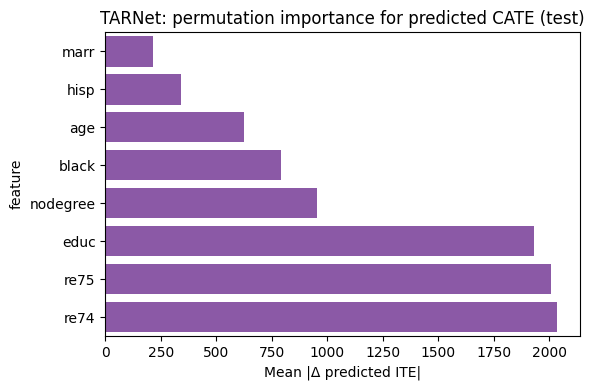

```python
n_rep = 8
rng = np.random.default_rng(4343)
ite_base = fit_tarnet.predict_cate(X_test)
imp = []
for j in range(X_test.shape[1]):
    deltas = []
    for _ in range(n_rep):
        Xp = X_test.copy()
        Xp[:, j] = rng.permutation(Xp[:, j])
        deltas.append(np.mean(np.abs(ite_base - fit_tarnet.predict_cate(Xp))))
    imp.append(np.mean(deltas))

imp_tarnet = pd.DataFrame({"feature": x_cols, "importance": imp}).sort_values("importance")
plt.figure(figsize=(6, 4))
sns.barplot(imp_tarnet, y="feature", x="importance", color="#8F4CB3")
plt.title("TARNet: permutation importance for predicted CATE (test)")
plt.xlabel("Mean |Δ predicted ITE|")
plt.tight_layout()
plt.show()
```

## Summary and Conclusion

TARNet learns a shared representation of covariates and separate heads for each treatment arm. In this notebook we fit TARNet alongside S- and T-Learner baselines on NSW data and compared ATE and factual MSE on a held-out test set.

- TARNet — Treatment-Agnostic Representation Network